# Building Assocation and Prediction Models for the Loans Dataset

```r
rm(list = ls())
library(tidyverse)
library(funModeling)
library(caret)
library(VIM)
library(mice)
library(ggcorrplot)
library(plotly)
library(pROC)
library(lubridate)
library(glmnet)
set.seed(1)
```

## Data Exploration

```r
setwd('/Users/shuheimiyasaka/Google Drive/Harvard/Courses/BST 260/BST-260-Final-Project')
load('loan.Rdata')
#loan.dat <- read.csv('loan.csv', header = TRUE)
#save(loan.dat, file = "./loan.RData")
#extract.3000 <- sample(1:dim(loan.dat)[1], 3000, replace = FALSE)
#write.csv(loan.dat[extract.3000, ], './loan_subset3000.csv')
```

```r
dim(loan.dat)
```

```
[1] 887379     74
```

```r
meta_loans <- funModeling::df_status(loan.dat, print_results = FALSE)
meta_loans
```

| variable | q_zeros | p_zeros | q_na | p_na | q_inf | p_inf | type | unique |
| --- | --- | --- | --- | --- | --- | --- | --- | --- |
| id | 0 | 0.00 | 0 | 0.00 | 0 | 0 | integer | 887379 |
| member_id | 0 | 0.00 | 0 | 0.00 | 0 | 0 | integer | 887379 |
| loan_amnt | 0 | 0.00 | 0 | 0.00 | 0 | 0 | numeric | 1372 |
| funded_amnt | 0 | 0.00 | 0 | 0.00 | 0 | 0 | numeric | 1372 |
| funded_amnt_inv | 233 | 0.03 | 0 | 0.00 | 0 | 0 | numeric | 9856 |
| term | 0 | 0.00 | 0 | 0.00 | 0 | 0 | factor | 2 |
| int_rate | 0 | 0.00 | 0 | 0.00 | 0 | 0 | numeric | 542 |
| installment | 0 | 0.00 | 0 | 0.00 | 0 | 0 | numeric | 68711 |
| grade | 0 | 0.00 | 0 | 0.00 | 0 | 0 | factor | 7 |
| sub_grade | 0 | 0.00 | 0 | 0.00 | 0 | 0 | factor | 35 |

[output cut: 64 more lines]

We have a data set with 887,379 records and 74 covariates. From the above table, we notice quite a few missing data.

```r
cols.2.remove <- c('id', 'member_id', 'url', 'desc')
```

We immediately ruled out the following covariates in our model: 1) id 2) member_id 3) url 4) desc

```r
meta_loans[order(-meta_loans$p_na),]
```

|  | variable | q_zeros | p_zeros | q_na | p_na | q_inf | p_inf | type | unique |
| --- | --- | --- | --- | --- | --- | --- | --- | --- | --- |
| 54 | annual_inc_joint | 0 | 0.00 | 886868 | 99.94 | 0 | 0 | numeric | 308 |
| 55 | dti_joint | 0 | 0.00 | 886870 | 99.94 | 0 | 0 | numeric | 449 |
| 66 | il_util | 138 | 0.02 | 868762 | 97.90 | 0 | 0 | numeric | 1272 |
| 64 | mths_since_rcnt_il | 13 | 0.00 | 866569 | 97.65 | 0 | 0 | numeric | 201 |
| 60 | open_acc_6m | 8246 | 0.93 | 866007 | 97.59 | 0 | 0 | numeric | 13 |
| 61 | open_il_6m | 2314 | 0.26 | 866007 | 97.59 | 0 | 0 | numeric | 35 |
| 62 | open_il_12m | 10806 | 1.22 | 866007 | 97.59 | 0 | 0 | numeric | 12 |
| 63 | open_il_24m | 5481 | 0.62 | 866007 | 97.59 | 0 | 0 | numeric | 17 |
| 65 | total_bal_il | 2259 | 0.25 | 866007 | 97.59 | 0 | 0 | numeric | 17030 |
| 67 | open_rv_12m | 7073 | 0.80 | 866007 | 97.59 | 0 | 0 | numeric | 18 |

[output cut: 64 more lines]

```r
missing.data.col <- meta_loans$variable[meta_loans$p_na > 10.]
cols.2.remove <- c(cols.2.remove, missing.data.col)
```

```r
meta_loans[order(meta_loans$unique),]
```

|  | variable | q_zeros | p_zeros | q_na | p_na | q_inf | p_inf | type | unique |
| --- | --- | --- | --- | --- | --- | --- | --- | --- | --- |
| 52 | policy_code | 0 | 0.00 | 0 | 0.00 | 0 | 0 | numeric | 1 |
| 6 | term | 0 | 0.00 | 0 | 0.00 | 0 | 0 | factor | 2 |
| 18 | pymnt_plan | 0 | 0.00 | 0 | 0.00 | 0 | 0 | factor | 2 |
| 36 | initial_list_status | 0 | 0.00 | 0 | 0.00 | 0 | 0 | factor | 2 |
| 53 | application_type | 0 | 0.00 | 0 | 0.00 | 0 | 0 | factor | 2 |
| 15 | verification_status | 0 | 0.00 | 0 | 0.00 | 0 | 0 | factor | 3 |
| 56 | verification_status_joint | 0 | 0.00 | 0 | 0.00 | 0 | 0 | factor | 4 |
| 13 | home_ownership | 0 | 0.00 | 0 | 0.00 | 0 | 0 | factor | 6 |
| 9 | grade | 0 | 0.00 | 0 | 0.00 | 0 | 0 | factor | 7 |
| 57 | acc_now_delinq | 883236 | 99.53 | 29 | 0.00 | 0 | 0 | numeric | 8 |

[output cut: 64 more lines]

```r
cols.2.remove <- c(cols.2.remove, 'policy_code')
```

We also decided to remove `policy_code` sign it only has one unique value

```r
cols.2.keep <- !(colnames(loan.dat) %in% cols.2.remove)
colnames(loan.dat)[cols.2.keep]
```

```
 [1] "loan_amnt"                  "funded_amnt"                "funded_amnt_inv"            "term"
 [5] "int_rate"                   "installment"                "grade"                      "sub_grade"
 [9] "emp_title"                  "emp_length"                 "home_ownership"             "annual_inc"
[13] "verification_status"        "issue_d"                    "loan_status"                "pymnt_plan"
[17] "purpose"                    "title"                      "zip_code"                   "addr_state"
[21] "dti"                        "delinq_2yrs"                "earliest_cr_line"           "inq_last_6mths"
[25] "open_acc"                   "pub_rec"                    "revol_bal"                  "revol_util"
[29] "total_acc"                  "initial_list_status"        "out_prncp"                  "out_prncp_inv"
[33] "total_pymnt"                "total_pymnt_inv"            "total_rec_prncp"            "total_rec_int"
[37] "total_rec_late_fee"         "recoveries"                 "collection_recovery_fee"    "last_pymnt_d"
[41] "last_pymnt_amnt"            "next_pymnt_d"               "last_credit_pull_d"         "collections_12_mths_ex_med"
[45] "application_type"           "verification_status_joint"  "acc_now_delinq"             "tot_coll_amt"
[49] "tot_cur_bal"                "total_rev_hi_lim"
```

```r
loan.dat.subset <- loan.dat[, cols.2.keep]
query = loan.dat$annual_inc == 0.
query.na = is.na(query)
if (sum(query.na) > 0){
  query[query.na] = TRUE
}
if (sum(query) > 0){
  loan.dat = loan.dat[!query,]
} else stop('expecting only one case!')
meta_loans <- funModeling::df_status(loan.dat.subset, print_results = FALSE)
meta_loans
```

| variable | q_zeros | p_zeros | q_na | p_na | q_inf | p_inf | type | unique |
| --- | --- | --- | --- | --- | --- | --- | --- | --- |
| loan_amnt | 0 | 0.00 | 0 | 0.00 | 0 | 0 | numeric | 1372 |
| funded_amnt | 0 | 0.00 | 0 | 0.00 | 0 | 0 | numeric | 1372 |
| funded_amnt_inv | 233 | 0.03 | 0 | 0.00 | 0 | 0 | numeric | 9856 |
| term | 0 | 0.00 | 0 | 0.00 | 0 | 0 | factor | 2 |
| int_rate | 0 | 0.00 | 0 | 0.00 | 0 | 0 | numeric | 542 |
| installment | 0 | 0.00 | 0 | 0.00 | 0 | 0 | numeric | 68711 |
| grade | 0 | 0.00 | 0 | 0.00 | 0 | 0 | factor | 7 |
| sub_grade | 0 | 0.00 | 0 | 0.00 | 0 | 0 | factor | 35 |
| emp_title | 0 | 0.00 | 0 | 0.00 | 0 | 0 | factor | 299273 |
| emp_length | 0 | 0.00 | 0 | 0.00 | 0 | 0 | factor | 12 |

[output cut: 40 more lines]

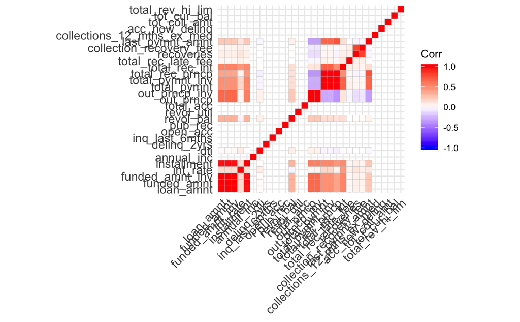

```r
numeric_cols <- meta_loans$variable[meta_loans$type == 'numeric']
ggcorrplot(cor(loan.dat.subset[,numeric_cols]))
```

```r
#aggr(loan.dat.subset, combined=T, cex.axis=0.6)
```

```r
# loan.dat = mice(loan.dat.subset, m=1)  # let's just impute one dataset
# loan.dat = complete(loan.dat.subset, 1)
```

Can’t impute since the dataset is too large.

```r
numeric_cols <- meta_loans$variable[meta_loans$type == 'numeric']
# par(mfrow=c(7,7), mar=c(3,1,1.5,1))
# for (j in 1:ncol(loan.dat.subset[numeric_cols])){
#   hist(loan.dat.subset[,j], xlab="", main=names(loan.dat.subset)[j])
# }
#
# # Scatterplot of y vs each variable
# par(mfrow=c(7,7),mar=c(3,1,1.5,1))
# for (j in 1:ncol(loan.dat.subset[numeric_cols])){
#   plot(D2[,j], y, xlab="", main=names(D2)[j], pch=20)
# }
```

```r
query <- loan.dat.subset$loan_status != 'Issued'
loan.dat.subset <- loan.dat.subset[query, ]
loan.dat.subset$loan_status_bin <- "Bad"
query = loan.dat.subset$loan_status == 'Fully Paid' | loan.dat.subset$loan_status == 'Current' |
  loan.dat.subset$loan_status == 'Does not meet the credit policy. Status:Fully Paid'
loan.dat.subset$loan_status_bin[query] = 'Good'
loan.dat.subset$loan_status_bin = as.factor(loan.dat.subset$loan_status_bin)
```

We also converted `funded_amnt_inv` to be percent funded amount by investors `perc_funded_amnt_inv`

```r
loan.dat.subset <- loan.dat.subset %>%
  mutate(perc_funded_amnt_inv = funded_amnt_inv/funded_amnt,
         issue_d = as.character(issue_d),
         term = as.character(term)) %>%
  mutate(year = as.numeric(str_sub(issue_d, start = -4)))
query <- loan.dat.subset$term == ' 36 months'
loan.dat.subset$term[query] = 'Short'
loan.dat.subset$term[!query] = 'Long'
loan.dat.subset$term = as.factor(loan.dat.subset$term)
query.na <- is.na(loan.dat.subset$tot_coll_amt)
if (sum(query.na) >0){
  loan.dat.subset$tot_coll_amt[query.na] = 0
}
loan.dat.subset <- loan.dat.subset %>%
  mutate(tot_coll_amt_gt0 = as.factor(tot_coll_amt > 0.))
```

```r
# keep a fifth of the data set to assess test performance
test.indx <- sample(1:dim(loan.dat.subset)[1], 200000, replace = FALSE)
train.indx <- setdiff(1:dim(loan.dat.subset)[1], test.indx)
```

We now onlhy have 50 convariates. after removing 24.

## Building a Prediction Model

```r
outcome <- c('loan_status_bin')
# think about adding zip_code back in
# if we run it on the cluster
predictors <- c('loan_amnt', 'funded_amnt',
                'int_rate', 'grade',
                'emp_length', 'home_ownership',
                'annual_inc', 'verification_status',
                'purpose',
                'addr_state', 'dti',
                'delinq_2yrs', 'inq_last_6mths',
                'open_acc', 'pub_rec',
                'revol_bal', 'revol_util',
                'total_acc', 'initial_list_status',
                'application_type', 'acc_now_delinq',
                'tot_coll_amt_gt0', 'tot_cur_bal',
                'total_rev_hi_lim', 'perc_funded_amnt_inv',
                'term', 'year')
loan.dat.subset <- loan.dat.subset[, c(outcome, predictors)]
meta_loans <- funModeling::df_status(loan.dat.subset, print_results = FALSE)
meta_loans[order(-meta_loans$p_na),]
```

|  | variable | q_zeros | p_zeros | q_na | p_na | q_inf | p_inf | type | unique |
| --- | --- | --- | --- | --- | --- | --- | --- | --- | --- |
| 24 | tot_cur_bal | 124 | 0.01 | 70276 | 8.00 | 0 | 0 | numeric | 325674 |
| 25 | total_rev_hi_lim | 284 | 0.03 | 70276 | 8.00 | 0 | 0 | numeric | 21087 |
| 18 | revol_util | 3501 | 0.40 | 499 | 0.06 | 0 | 0 | numeric | 1356 |
| 1 | loan_status_bin | 0 | 0.00 | 0 | 0.00 | 0 | 0 | factor | 2 |
| 2 | loan_amnt | 0 | 0.00 | 0 | 0.00 | 0 | 0 | numeric | 1372 |
| 3 | funded_amnt | 0 | 0.00 | 0 | 0.00 | 0 | 0 | numeric | 1372 |
| 4 | int_rate | 0 | 0.00 | 0 | 0.00 | 0 | 0 | numeric | 541 |
| 5 | grade | 0 | 0.00 | 0 | 0.00 | 0 | 0 | factor | 7 |
| 6 | emp_length | 0 | 0.00 | 0 | 0.00 | 0 | 0 | factor | 12 |
| 7 | home_ownership | 0 | 0.00 | 0 | 0.00 | 0 | 0 | factor | 6 |

[output cut: 18 more lines]

```r
sum(is.na(loan.dat.subset$loan_status_bin))
```

```
[1] 0
```

```r
for (j in 1:ncol(loan.dat.subset)){
  miss = is.na(loan.dat.subset[,j])
  if (sum(miss) > 0){
    loan.dat.subset[miss, j] = mean(loan.dat.subset[,j], na.rm=T)
  }
}
sum(is.na(loan.dat.subset))
```

```
[1] 0
```

```r
summary(loan.dat.subset)
```

```
 loan_status_bin   loan_amnt      funded_amnt       int_rate     grade          emp_length      home_ownership     annual_inc
 Bad : 67429     Min.   :  500   Min.   :  500   Min.   : 5.32   A:146754   10+ years:288752   ANY     :     3   Min.   :      0
 Good:811490     1st Qu.: 8000   1st Qu.: 8000   1st Qu.: 9.99   B:252006   2 years  : 78167   MORTGAGE:439337   1st Qu.:  45000
                 Median :13000   Median :13000   Median :12.99   C:243388   < 1 year : 69832   NONE    :    50   Median :  64800
                 Mean   :14750   Mean   :14737   Mean   :13.25   D:138357   3 years  : 69344   OTHER   :   182   Mean   :  74996
                 3rd Qu.:20000   3rd Qu.:20000   3rd Qu.:16.20   E: 70112   1 year   : 56547   OWN     : 86432   3rd Qu.:  90000
                 Max.   :35000   Max.   :35000   Max.   :28.99   F: 22852   5 years  : 55194   RENT    :352915   Max.   :9500000
                                                                 G:  5450   (Other)  :261083
      verification_status               purpose         addr_state          dti           delinq_2yrs      inq_last_6mths
 Not Verified   :263971   debt_consolidation:519419   CA     :128370   Min.   :   0.00   Min.   : 0.0000   Min.   : 0.0000
 Source Verified:326722   credit_card       :204111   NY     : 73364   1st Qu.:  11.90   1st Qu.: 0.0000   1st Qu.: 0.0000
 Verified       :288226   home_improvement  : 51336   TX     : 70447   Median :  17.64   Median : 0.0000   Median : 0.0000
                          other             : 42414   FL     : 60328   Mean   :  18.14   Mean   : 0.3141   Mean   : 0.6952
                          major_purchase    : 17093   IL     : 35178   3rd Qu.:  23.93   3rd Qu.: 0.0000   3rd Qu.: 1.0000
                          small_business    : 10265   NJ     : 32960   Max.   :9999.00   Max.   :39.0000   Max.   :33.0000
                          (Other)           : 34281   (Other):478272
    open_acc        pub_rec          revol_bal         revol_util      total_acc      initial_list_status   application_type
 Min.   : 0.00   Min.   : 0.0000   Min.   :      0   Min.   :  0.0   Min.   :  1.00   f:456028            INDIVIDUAL:878472
 1st Qu.: 8.00   1st Qu.: 0.0000   1st Qu.:   6446   1st Qu.: 37.7   1st Qu.: 17.00   w:422891            JOINT     :   447
 Median :11.00   Median : 0.0000   Median :  11875   Median : 56.0   Median : 24.00
 Mean   :11.54   Mean   : 0.1948   Mean   :  16912   Mean   : 55.1   Mean   : 25.26
 3rd Qu.:14.00   3rd Qu.: 0.0000   3rd Qu.:  20823   3rd Qu.: 73.6   3rd Qu.: 32.00
 Max.   :90.00   Max.   :86.0000   Max.   :2904836   Max.   :892.3   Max.   :169.00

 acc_now_delinq      tot_coll_amt_gt0  tot_cur_bal      total_rev_hi_lim  perc_funded_amnt_inv    term             year
 Min.   : 0.000000   FALSE:764177     Min.   :      0   Min.   :      0   Min.   :0.0000       Long :263776   Min.   :2007
 1st Qu.: 0.000000   TRUE :114742     1st Qu.:  32250   1st Qu.:  14700   1st Qu.:1.0000       Short:615143   1st Qu.:2013
 Median : 0.000000                    Median : 100279   Median :  25800   Median :1.0000                      Median :2014
 Mean   : 0.004994                    Mean   : 139393   Mean   :  32035   Mean   :0.9964                      Mean   :2014
 3rd Qu.: 0.000000                    3rd Qu.: 195605   3rd Qu.:  37800   3rd Qu.:1.0000                      3rd Qu.:2015
 Max.   :14.000000                    Max.   :8000078   Max.   :9999999   Max.   :1.0000                      Max.   :2015
```

```r
save(list(fit.ridge, fit.lasso, fit.enet), file = "./models.RData")
```

[output not shown]

## Building an Assocation Model